# Praca Domowa 6

Krzysztof Kosz

# **Treemap**

W tej pracy domowej skupiłem się na pakiecie Treemap (oraz pakiecie umożliwiającym nadanie interaktywnego charakteru wykresom w stylu treemap - d3treeR). Pakiet treemap pozwala tworzyć mapy drzewa, które umożliwiają wyświetlanie hierarchicznych danych w strukturze zagnieżdżonych kwadratów (czyli jak sama nazwa mówi tworzy mapę strukury danych jaką jest drzewo). Jednak po stworzeniu wizualizacji z większą ilością zagnieżdżonych danych niż 2 poziomy doszedłem do wniosku, iż nie jest ona zbyt czytelna. Postanowiłem sprawić, aby wykres ten był interaktywny, co ułatwi jego odczytywanie, dlatego zająłem się pakietem d3treeR. Pozwala on na płynne przechodzenie po mapie drzewa, wchodząc na kolejne poziomy zagnieżdżenia.

Aby stworzyć wizualizację w tym pakiecie, stworzyłem zbiór danych odnośnie ilości występów Roberta Lewandowskiego w różnych rozgrywkach. Podzieliłem występy najpierw na kraje, w których grał on w danym momencie, następnie na kluby, a w końcu na rozgrywki.

Poniżej wstawiam kod z wizualizacją (najpierw bez interaktywności, a następnie już z nią). Nawigacja po interaktywnym wykresie wygląda następująco: chcąc wejść w daną część mapy klikamy na nią, natomiast chcąc wrócić do wcześniejszego poziomu klikamy górny pasek.

```r
library(treemap)
library(d3treeR)

df<-data.frame(
  kraj=c(rep("Polska", times=6), rep("Niemcy", times=9), rep("Hiszpania", times=2)),
  klub=c("Znicz Pruszków", rep("Lech Poznań", times=5), rep("Borussia Dortmund", times=5), rep("Bayern Monachium", times=4), rep("FC Barcelona", times=2)),
  rozgrywki=c("Fortuna 1 liga",
              "Ekstraklasa", "Fortuna Puchar Polski", "Kwalifikacje do Ligi Europy", "Liga Europy", "Superpuchar Polski",
              "Bundesliga", "Liga Mistrzów", "Liga Europy", "DFB-Pokal", "Inne",
              "Bundesliga", "Liga Mistrzów", "SuperCup", "Inne",
              "La Liga", "Liga Mistrzów"),
  wystepy=c(32, 58, 7, 4, 8, 1, 131, 28, 6, 17, 5, 253, 78, 33, 11, 14, 5),
  stringsAsFactors = FALSE
)

p<-treemap(df,
        index=c("kraj", "klub", "rozgrywki"),
        vSize="wystepy",
        type="index",
        palette='Set1')
```

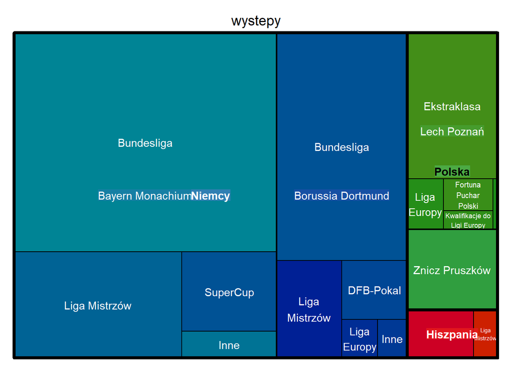

```r
inter <- d3tree2( p ,  rootname = "Występy Roberta Lewandowskiego w rozgrywkach klubowych" )
inter
```

[interactive chart not shown]

# **Podsumowanie**

Jest to ciekawy pakiet, aczkolwiek po (niedługiej co prawda) pracy z nim uważam, że ciężko w nim tworzyć eleganckie, ładnie wyglądające wizualizacje. Szczerze wątpię, że kiedyś go użyje, ale ciekawie było go poznać.